TELECOM Paris Oct-Nov-2021

Projet final du Kit Data Science 2021

# Ci-dessous le plan du travail

**1) Téléchargement et chargement des données des classements dans un Data Frame** :

- Téléchargement des fichiers excels des classement: Utilisation de BeautifulSoup et urllib
- Correction des fichiers Excel pour permettre l'ouverture avec pandas: Utilisation de win32com
- Chargement du dataset des classements : Utilisation de pd.append()
- Nettoyage des données des classements.
- Affichage et exploration des données

**2) Téléchargement et chargement des caractéristiques téchniques des voiliers** :

- Téléchargement des données techniques des voiliers et construction du Dataset : Utilisation de BeautifulSoup
- Nettoyage des données techniques des voiliers
- Affichage et exploration des données

**3) Rapprochement entres les classements et les caractéristiques techniques**

- Utilisation de pd.merge pour merger les données :

  ```
    NB: Nous utilisons la colone "Nom Skipper" pour la jointure des deux Data Frame
  ```

- Renommage des colones du nouveau Data set
- Affichage et exploiration des données

**4) Mise en place des tests de conformité sur les données**

- Test de conformité sur les données du Classement
- Test de conformité sur les données techniques
- Test de conformité sur la jointure des deux datasets

**5) Affichage du Dataframe final**

- visualisation de quelques samples data avec df.head()

**6) Statistiques de course**

**7 ) Analyses sur les données**

- Corrélation et régression linéaire entre le classement (rang) et la vitesse utile (VMG) des voiliers.
- Visualisation du Rang et de la vitesse utile par voilier
- Impact de la présence d'un foil sur le classement et la vitesse des voiliers.
- Visualisation de la distance parcourue par voilier.
- Cartes avec les routes d'un ou plusieurs voiliers.

**8) Visualisation du parcours des voiliers sur la carte**

## Importation des librairies à utiliser

```python
import requests
import urllib.request
from bs4 import BeautifulSoup
import pandas as pd
import numpy as np
import glob
import locale
locale.setlocale(locale.LC_ALL, 'fr_FR')
import re
import matplotlib.pyplot as plt
import seaborn as sns
import win32com.client
import os
```

## **1) Extraction des données**

**a) Téléchargement des fichiers Excel des classements**

```python
#recuperation des horaires de classements des voiliers avec BeautifulSoup
#Téléchargement des classements

def download_classements():

    r = requests.get("https://www.vendeeglobe.org/fr/classement/")

    # str en précisant un encodage
    content = r.content.decode('utf-8')
    soup = BeautifulSoup(content)

    classements =[]
    for option in soup.find("select" , attrs={"class":"form__input m--select onsubmit-rank"}).findAll('option')[1:]:
        classement= 'https://www.vendeeglobe.org/download-race-data/vendeeglobe_'+option.attrs['value']+'.xlsx'
        urllib.request.urlretrieve(classement, 'download/'+classement.split('/')[-1])
```

```python
#appel de la fonction pour le téléchargement des données
download_classements()
```

**b) transformation des fichiers en un contenu exploitable par pandas.read...**

```python
#Utilisation de win32com pour la correction de nos fichiers
def correction_fichiers(input_folder='download', output_folder='classements'):
    current_dir = os. getcwd()
    file_dir  = current_dir+'\\'+input_folder
    for filename in os.listdir(file_dir):
        file= os.path.splitext(filename)[0]
        o = win32com.client.Dispatch("Excel.Application")
        o.Visible = False
        wb = o.Workbooks.Open(current_dir+"\\"+input_folder+"\\" + file)
        wb.ActiveSheet.SaveAs(current_dir+"\\"+output_folder+"\\" + file + ".xlsx", 51)
        o.Application.Quit()
```

```python
#appel de la fonction pour la correction des fichiers
correction_fichiers(input_folder='download', output_folder='classements')
```

**c) chargement et concatenation du dataset des classements**

```python
#Fonction de chargement du dataset des classements

def load_df_classements(input_directory='classements/*'):
    columns=pd.MultiIndex.from_tuples((('Rang',''),('Nat./Voile',''),('Skipper/Bateau',''),('Heure FR',''),('Latitude',''),('Longitude',''),('Depuis 30 minutes','Cap'),('Depuis 30 minutes','Vitesse'),('Depuis 30 minutes','VMG'),('Depuis 30 minutes','Distance'),('Depuis le dernier classement','Cap'),('Depuis le dernier classement','Vitesse'),('Depuis le dernier classement','VMG'),('Depuis le dernier classement','Distance'),('Depuis 24 heures','Cap'),('Depuis 24 heures','Vitesse'),('Depuis 24 heures','VMG'),('Depuis 24 heures','Distance'),('DTF',''),('DTL','')))


    data_files = glob.glob(input_directory)

    #NB: Le classement du 8 Novembre à 12h n'est pas pris en compte car vide
    #NB: Nous nous arretons le 27 janvier 2021 à 14h qui est la date du premier arrivé . (Le format du fichier change à partir de cette date)
    data_files = list(filter(lambda fichier: '20201108_140000' <= fichier[-20:-5] <= '20210127_140000', data_files))
    df = pd.DataFrame()
    for filename in data_files:
        excel= pd.read_excel(filename,'fr',header=[3,4],skiprows=range(38,45))
        excel=excel.iloc[:,1:]
        excel.columns=columns
        excel['Date'] = filename[-20:-5]

        df = df.append(excel, ignore_index=True)

    return df
```

```python
#chargement et affichage
df=load_df_classements('classements/*')
df.head()
```

|  | Rang | Nat./Voile | Skipper/Bateau | Heure FR | Latitude | Longitude | Depuis 30 minutes Cap | Depuis 30 minutes Vitesse | Depuis 30 minutes VMG | Depuis 30 minutes Distance | ... | Depuis le dernier classement Vitesse | Depuis le dernier classement VMG | Depuis le dernier classement Distance | Depuis 24 heures Cap | Depuis 24 heures Vitesse | Depuis 24 heures VMG | Depuis 24 heures Distance | DTF | DTL | Date |
| --- | --- | --- | --- | --- | --- | --- | --- | --- | --- | --- | --- | --- | --- | --- | --- | --- | --- | --- | --- | --- | --- |
| 0 | 1 | \nFRA 18 | Louis Burton\nBureau Vallée 2 | 15:30 FR\n | 46°24.46'N | 01°50.48'W | 241° | 17.7 kts | 17.5 kts | 0.3 nm | ... | 0.0 kts | 0.0 kts | 2788.0 nm | 201° | 0.3 kts | 0.3 kts | 6.1 nm | 24293.9 nm | 0.0 nm | 20201108_140000 |
| 1 | 2 | \nMON 10 | Boris Herrmann\nSeaexplorer - Yacht Club De Mo... | 15:31 FR\n1min | 46°24.34'N | 01°49.82'W | 241° | 11.1 kts | 10.9 kts | 0.4 nm | ... | 0.0 kts | 0.0 kts | 2787.9 nm | 196° | 0.3 kts | 0.2 kts | 6.0 nm | 24294.2 nm | 0.4 nm | 20201108_140000 |
| 2 | 3 | \nFRA 8 | Jérémie Beyou\nCharal | 15:30 FR\n | 46°24.91'N | 01°49.99'W | 244° | 15.5 kts | 15.5 kts | 0.5 nm | ... | 0.0 kts | 0.0 kts | 2788.5 nm | 199° | 0.2 kts | 0.2 kts | 5.5 nm | 24294.3 nm | 0.5 nm | 20201108_140000 |
| 3 | 4 | \nFRA 59 | Thomas Ruyant\nLinkedOut | 15:30 FR\n | 46°24.71'N | 01°49.68'W | 244° | 13.2 kts | 13.1 kts | 0.7 nm | ... | 0.0 kts | 0.0 kts | 2788.3 nm | 196° | 0.2 kts | 0.2 kts | 5.6 nm | 24294.5 nm | 0.6 nm | 20201108_140000 |
| 4 | 5 | \nFRA 53 | Maxime Sorel\nV And B Mayenne | 15:30 FR\n | 46°24.59'N | 01°49.56'W | 246° | 10.9 kts | 10.9 kts | 0.2 nm | ... | 0.0 kts | 0.0 kts | 2788.1 nm | 195° | 0.8 kts | 0.7 kts | 5.8 nm | 24294.5 nm | 0.6 nm | 20201108_140000 |

5 rows × 21 columns

```python
df.info()
```

```
<class 'pandas.core.frame.DataFrame'>
RangeIndex: 15906 entries, 0 to 15905
Data columns (total 21 columns):
 #   Column                                    Non-Null Count  Dtype
---  ------                                    --------------  -----
 0   (Rang, )                                  15906 non-null  object
 1   (Nat./Voile, )                            15906 non-null  object
 2   (Skipper/Bateau, )                        15906 non-null  object
 3   (Heure FR, )                              13703 non-null  object
 4   (Latitude, )                              13703 non-null  object
 5   (Longitude, )                             13703 non-null  object
 6   (Depuis 30 minutes, Cap)                  13703 non-null  object
 7   (Depuis 30 minutes, Vitesse)              13703 non-null  object
 8   (Depuis 30 minutes, VMG)                  13703 non-null  object
 9   (Depuis 30 minutes, Distance)             13703 non-null  object
 10  (Depuis le dernier classement, Cap)       13703 non-null  object
 11  (Depuis le dernier classement, Vitesse)   13703 non-null  object
 12  (Depuis le dernier classement, VMG)       13703 non-null  object
 13  (Depuis le dernier classement, Distance)  13703 non-null  object
 14  (Depuis 24 heures, Cap)                   13703 non-null  object
 15  (Depuis 24 heures, Vitesse)               13703 non-null  object
 16  (Depuis 24 heures, VMG)                   13703 non-null  object
 17  (Depuis 24 heures, Distance)              13703 non-null  object
 18  (DTF, )                                   13703 non-null  object
 19  (DTL, )                                   13703 non-null  object
 20  (Date, )                                  15906 non-null  object
dtypes: object(21)
memory usage: 2.5+ MB
```

**d) Nettoyage des données**

```python
#fonction de convertion des coordonnées gps DMS
def conversion(coord):
    directions = {'N':1, 'S':-1, 'E': 1, 'W':-1}
    result = coord.replace(u'°',' ').replace('\'',' ').replace('.',' ')
    result = result.split()
    direction = result.pop()
    result.extend([0,0,0])
    return (int(result[0])+int(result[1])/60.0+int(result[2])/3600.0) * directions[direction]

#Nettoyage du dataset
def nettoyage_classements(df):
    #### nettoyage du rang
    df=df.copy()
    df=df[(df['Rang']!='RET') & (df['Rang']!='NL')]
    df['Rang']=df['Rang'].astype(int)

    #Nettoyage de la colone Nat./Voile
    #NB: on transforme la valeur FRFRA 02 en FRA 02 et FRFRA 69 en FRA 69
    df['Nat./Voile']=df.loc[:,'Nat./Voile'].str.replace('\n','')
    df['Nat./Voile'].value_counts().sort_index()
    df.loc[df['Nat./Voile']=='FRFRA 02','Nat./Voile']='FRA 02'
    df.loc[df['Nat./Voile']=='FRFRA 69','Nat./Voile']='FRA 69'
    #Ajout de la colone Id Voile
    df['Id voile']=df['Nat./Voile'].str.extract('[a-zA-Z]+ (\d+)')[0].astype(int)

    #Nettoyage de la variable Skipper/Bateau

    df[['Skipper','Bateau']]  =df['Skipper/Bateau'].str.extract('(.*)\n(.*)')
    df=df.drop('Skipper/Bateau',axis=1,level=0)

    #Tranformation du Bateau 'HUGO BOSS' en 'Hugo Boss'
    df['Bateau']= df['Bateau'].apply(lambda x: 'Hugo Boss' if str(x)=='HUGO BOSS' else x )

    #Nettoyage de l'heure
    var=df['Heure FR'].str.extract('(.*) FR\n(\d*\w*)')
    var[1]=var[1].apply(lambda x: '0min' if x=='' else x)
    df['Heure FR'] = (pd.to_datetime(var[0]+':00',format='%H:%M:%S')-pd.to_timedelta(var[1]) ).dt.strftime('%H:%M:%S')

    #Nettoyage de DTF
    df['DTF']= df['DTF'].str.extract('(.*) nm').astype(float)[0]

    #Nettoyage de DTL
    df['DTL']= df['DTL'].str.extract('(.*) nm').astype(float)[0]

    #Nettoyage de la distance
    df[('Depuis 30 minutes','Distance')]= df[('Depuis 30 minutes','Distance')].str.extract('(\d+.?\d*)\s?\w*').astype(float)
    df[('Depuis le dernier classement','Distance')]= df[('Depuis le dernier classement','Distance')].str.extract('(\d+.?\d*)\s?\w*').astype(float)
    df[('Depuis 24 heures','Distance')]= df[('Depuis 24 heures','Distance')].str.extract('(\d+.?\d*)\s?\w*').astype(float)

    #Nettoyage de la variable VMG
    df[('Depuis 30 minutes','VMG')]= df[('Depuis 30 minutes','VMG')].str.extract('(.*) kts').astype(float)
    df[('Depuis le dernier classement','VMG')]= df[('Depuis le dernier classement','VMG')].str.extract('(.*) kts').astype(float)
    df[('Depuis 24 heures','VMG')]= df[('Depuis 24 heures','VMG')].str.extract('(.*) kts').astype(float)

    #Nettoyage de la vitesse
    df[('Depuis 30 minutes','Vitesse')]= df[('Depuis 30 minutes','Vitesse')].str.extract('(.*) kts').astype(float)
    df[('Depuis le dernier classement','Vitesse')]= df[('Depuis le dernier classement','Vitesse')].str.extract('(.*) kts').astype(float)
    df[('Depuis 24 heures','Vitesse')]= df[('Depuis 24 heures','Vitesse')].str.extract('(.*) kts').astype(float)

    #Nettoyage du cap
    df[('Depuis 30 minutes','Cap')]= df[('Depuis 30 minutes','Cap')].str[:-1].astype(int)
    df[('Depuis le dernier classement','Cap')]= df[('Depuis le dernier classement','Cap')].str[:-1].astype(int)
    df[('Depuis 24 heures','Cap')]= df[('Depuis 24 heures','Cap')].str[:-1].astype(int)

    #Nettoyage de la date
    df['Date']=pd.to_datetime(df['Date'], format="%Y%m%d_%H%M%S")
    df.set_index(df['Date'], drop=True, inplace=True)
    df=df.drop('Date',axis=1,level=0)
    df.index.rename('Date classement', inplace=True)

    #convertion de latitude et longitude
    df[['Latitude','Longitude']]=df[['Latitude','Longitude']].applymap(conversion)

    return df
```

```python
#Nettoyage et affichage des resultats
df_cleaned=nettoyage_classements(df)
df_cleaned.head()
```

| Date classement | Rang | Nat./Voile | Heure FR | Latitude | Longitude | Depuis 30 minutes Cap | Depuis 30 minutes Vitesse | Depuis 30 minutes VMG | Depuis 30 minutes Distance | Depuis le dernier classement Cap | Depuis le dernier classement ... | Depuis le dernier classement Distance | Depuis 24 heures Cap | Depuis 24 heures Vitesse | Depuis 24 heures VMG | Depuis 24 heures Distance | DTF | DTL | Id voile | Skipper | Bateau |
| --- | --- | --- | --- | --- | --- | --- | --- | --- | --- | --- | --- | --- | --- | --- | --- | --- | --- | --- | --- | --- | --- |
| 2020-11-08 14:00:00 | 1 | FRA 18 | 15:30:00 | 46.412778 | -1.846667 | 241 | 17.7 | 17.5 | 0.3 | 357 | ... | 2788.0 | 201 | 0.3 | 0.3 | 6.1 | 24293.9 | 0.0 | 18 | Louis Burton | Bureau Vallée 2 |
| 2020-11-08 14:00:00 | 2 | MON 10 | 15:30:00 | 46.409444 | -1.839444 | 241 | 11.1 | 10.9 | 0.4 | 357 | ... | 2787.9 | 196 | 0.3 | 0.2 | 6.0 | 24294.2 | 0.4 | 10 | Boris Herrmann | Seaexplorer - Yacht Club De Monaco |
| 2020-11-08 14:00:00 | 3 | FRA 8 | 15:30:00 | 46.425278 | -1.844167 | 244 | 15.5 | 15.5 | 0.5 | 357 | ... | 2788.5 | 199 | 0.2 | 0.2 | 5.5 | 24294.3 | 0.5 | 8 | Jérémie Beyou | Charal |
| 2020-11-08 14:00:00 | 4 | FRA 59 | 15:30:00 | 46.419722 | -1.835556 | 244 | 13.2 | 13.1 | 0.7 | 357 | ... | 2788.3 | 196 | 0.2 | 0.2 | 5.6 | 24294.5 | 0.6 | 59 | Thomas Ruyant | LinkedOut |
| 2020-11-08 14:00:00 | 5 | FRA 53 | 15:30:00 | 46.416389 | -1.832222 | 246 | 10.9 | 10.9 | 0.2 | 357 | ... | 2788.1 | 195 | 0.8 | 0.7 | 5.8 | 24294.5 | 0.6 | 53 | Maxime Sorel | V And B Mayenne |

5 rows × 22 columns

```python
df_cleaned.info()
```

```
<class 'pandas.core.frame.DataFrame'>
DatetimeIndex: 13703 entries, 2020-11-08 14:00:00 to 2021-01-27 14:00:00
Data columns (total 22 columns):
 #   Column                                    Non-Null Count  Dtype
---  ------                                    --------------  -----
 0   (Rang, )                                  13703 non-null  int32
 1   (Nat./Voile, )                            13703 non-null  object
 2   (Heure FR, )                              13703 non-null  object
 3   (Latitude, )                              13703 non-null  float64
 4   (Longitude, )                             13703 non-null  float64
 5   (Depuis 30 minutes, Cap)                  13703 non-null  int32
 6   (Depuis 30 minutes, Vitesse)              13703 non-null  float64
 7   (Depuis 30 minutes, VMG)                  13703 non-null  float64
 8   (Depuis 30 minutes, Distance)             13703 non-null  float64
 9   (Depuis le dernier classement, Cap)       13703 non-null  int32
 10  (Depuis le dernier classement, Vitesse)   13703 non-null  float64
 11  (Depuis le dernier classement, VMG)       13703 non-null  float64
 12  (Depuis le dernier classement, Distance)  13703 non-null  float64
 13  (Depuis 24 heures, Cap)                   13703 non-null  int32
 14  (Depuis 24 heures, Vitesse)               13703 non-null  float64
 15  (Depuis 24 heures, VMG)                   13703 non-null  float64
 16  (Depuis 24 heures, Distance)              13703 non-null  float64
 17  (DTF, )                                   13703 non-null  float64
 18  (DTL, )                                   13703 non-null  float64
 19  (Id voile, )                              13703 non-null  int32
 20  (Skipper, )                               13703 non-null  object
 21  (Bateau, )                                13703 non-null  object
dtypes: float64(13), int32(5), object(4)
memory usage: 2.1+ MB
```

## **2) Extraction des caractéristiques techniques de chacun des voiliers.**

**a) Téléchargements des caractéristiques techniques sur les voiles**

```python
#fonction de téléchargement avec BeautifulSoup
def get_caracteristiques_technique():
    r_caract = requests.get("https://www.vendeeglobe.org/fr/glossaire")
    content_caract = r_caract.content.decode('utf-8')
    soup_caract = BeautifulSoup(content_caract)
    caractéristiques=[]
    for voilier in soup_caract.findAll("div" , attrs={"class":"sv-u-1 sv-u-s-1-2 sv-u-m-1-3 sv-u-l-1-6"}) :
        instance = {item.text.split(':')[0].strip():item.text.split(':')[1].strip() for item in voilier.findAll('li')}
        instance['Lien image']=voilier.find('img').attrs['src']
        instance['Nom voilier']=voilier.find('h3', attrs={'class':'boats-list__boat-name'}).text
        instance['Nom skipper']=voilier.find('span', attrs={'class':'boats-list__skipper-name'}).text

        caractéristiques.append(instance)
    #creation du dataFrame
    df_tech =pd.DataFrame(caractéristiques)
    return df_tech
```

```python
#Extraction et affichage
df_tech=get_caracteristiques_technique()
df_tech.head()
```

|  | Numéro de voile | Anciens noms du bateau | Architecte | Chantier | Date de lancement | Longueur | Largeur | Tirant d'eau | Déplacement (poids) | Nombre de dérives | Hauteur mât | Voile quille | Surface de voiles au près | Surface de voiles au portant | Lien image | Nom voilier | Nom skipper |
| --- | --- | --- | --- | --- | --- | --- | --- | --- | --- | --- | --- | --- | --- | --- | --- | --- | --- |
| 0 | FRA 56 | No Way Back, Vento di Sardegna | VPLP/Verdier | Persico Marine | 01 Août 2015 | 18,28 m | 5,85 m | 4,50 m | 7 t | foils | 29 m | monotype | 320 m2 | 570 m2 | /medias/05/08/50821/image-r-0-280.png | NEWREST - ART & FENÊTRES | Fabrice AMEDEO |
| 1 | FRA 49 | Gitana Eighty, Synerciel, Newrest-Matmut | Bruce Farr Design | Southern Ocean Marine (Nouvelle Zélande) | 08 Mars 2007 | 18,28m | 5,80m | 4,50m | 9t | 2 | 28m | acier forgé | 280 m2 | 560 m2 | /medias/05/06/50663/image-r-0-280.png | PURE - Best Western® | Romain ATTANASIO |
| 2 | FRA72 | Famille Mary-Etamine du Lys, Initiatives Coeur... | Marc Lombard | MAG France | 01 Mars 1998 | 18,28m | 5,54m | 4,50m | 9t | 2 | 29 m | acier | 260 m2 | 580 m2 | /medias/05/04/50477/image-r-0-280.png | TSE - 4MYPLANET | Alexia BARRIER |
| 3 | 17 | Safran 2 - Des Voiles et Vous | Verdier - VPLP | CDK Technologies | 12 Mars 2015 | 18,28 m | 5,80 m | 4,50 m | 8 t | foils | 29 m | acier mécano soudé | 310 m2 | 550 m2 | /medias/05/08/50815/image-r-0-280.png | Maître CoQ IV | Yannick BESTAVEN |
| 4 | 08 | NaN | VPLP | CDK Technologies | 18 Août 2018 | 18,28 m | 5,85 m | 4,50 m | 8t | foils | 29 m | acier | 320 m2 | 600 m2 | /medias/05/04/50486/image-r-0-280.png | CHARAL | Jérémie BEYOU |

**b) Nettoyage des caractéristiques techniques des voiles**

```python
#Fonction de Nettoyage

def nettoyage_caracteristiques_technique(df_tech):
    #Nettoyage du numero de voile
    #NB: Le voile de numero NAN correspond à  FRA 59 Thomas Ruyant
    df_tech.loc[df_tech['Numéro de voile'].isna(),'Numéro de voile']='FRA 59'
    var=df_tech['Numéro de voile'].str.extract('([a-zA-Z]*)\s*(\d+)')
    df_tech['Numéro de voile']=var[0]+' '+var[1]

    #Ajout de la colone Id Voile
    df_tech['Id voile']=df_tech['Numéro de voile'].str.extract('[a-zA-Z]*\s*(\d+)')[0].astype(int)
    #Nettoyage de Anciens noms du bateau

    #Nettoyage de Date de lancement
    df_tech['Date de lancement']=pd.to_datetime(df_tech['Date de lancement'], format="%d %B %Y")

    #Nettoyage de Longueur , largeur , Tirant d'eau , Hauteur mât ,Surface de voiles au près,Surface de voiles au portant,Déplacement (poids)
    df_tech['Longueur']=df_tech['Longueur'].str.extract('(\d+,*\d+)\s*m')[0].str.replace(',','.').astype(float)
    df_tech['Largeur']=df_tech['Largeur'].str.extract('(\d+\,*\d+)\s*m')[0].str.replace(',','.').astype(float)
    df_tech["Tirant d'eau"]=df_tech["Tirant d'eau"].str.extract('(\d+\,*\d+)\s*m')[0].str.replace(',','.').astype(float)
    df_tech["Hauteur mât"]=df_tech["Hauteur mât"].str.extract('(\d+\,*\d+)\s*m?')[0].str.replace(',','.').astype(float)
    df_tech["Surface de voiles au près"]=df_tech["Surface de voiles au près"].str.extract('(\d+)\s*.*')[0].astype(float)
    df_tech["Surface de voiles au portant"]=df_tech["Surface de voiles au portant"].str.extract('(\d+)\s*.*')[0].astype(float)
    df_tech["Déplacement (poids)"]=df_tech["Déplacement (poids)"].str.extract('(\d+\,*\d*)\s*.*')[0].str.replace(',','.').astype(float)

    #Nettoyage de du nom du skipper et suppression des caractères invisibles
    #NB: Arnaud BOISSIÈRES change en Arnaud BOISSIERES pour etre conforme aux classements
    #NB: Sam DAVIES change en Samantha DAVIES
    df_tech['Nom skipper']=df_tech['Nom skipper'].apply(lambda x: re.sub('\W+',' ',x).strip())
    df_tech.loc[df_tech['Nom skipper']=='Arnaud BOISSIÈRES','Nom skipper']='Arnaud BOISSIERES'
    df_tech.loc[df_tech['Nom skipper']=='Sam DAVIES','Nom skipper']='Samantha DAVIES'

    return df_tech
```

```python
#Nettoyage et affichage
df_tech_cleaned=nettoyage_caracteristiques_technique(df_tech.copy())
df_tech_cleaned.head()
```

|  | Numéro de voile | Anciens noms du bateau | Architecte | Chantier | Date de lancement | Longueur | Largeur | Tirant d'eau | Déplacement (poids) | Nombre de dérives | Hauteur mât | Voile quille | Surface de voiles au près | Surface de voiles au portant | Lien image | Nom voilier | Nom skipper | Id voile |
| --- | --- | --- | --- | --- | --- | --- | --- | --- | --- | --- | --- | --- | --- | --- | --- | --- | --- | --- |
| 0 | FRA 56 | No Way Back, Vento di Sardegna | VPLP/Verdier | Persico Marine | 2015-08-01 | 18.28 | 5.85 | 4.5 | 7.0 | foils | 29.0 | monotype | 320.0 | 570.0 | /medias/05/08/50821/image-r-0-280.png | NEWREST - ART & FENÊTRES | Fabrice AMEDEO | 56 |
| 1 | FRA 49 | Gitana Eighty, Synerciel, Newrest-Matmut | Bruce Farr Design | Southern Ocean Marine (Nouvelle Zélande) | 2007-03-08 | 18.28 | 5.80 | 4.5 | 9.0 | 2 | 28.0 | acier forgé | 280.0 | 560.0 | /medias/05/06/50663/image-r-0-280.png | PURE - Best Western® | Romain ATTANASIO | 49 |
| 2 | FRA 72 | Famille Mary-Etamine du Lys, Initiatives Coeur... | Marc Lombard | MAG France | 1998-03-01 | 18.28 | 5.54 | 4.5 | 9.0 | 2 | 29.0 | acier | 260.0 | 580.0 | /medias/05/04/50477/image-r-0-280.png | TSE - 4MYPLANET | Alexia BARRIER | 72 |
| 3 | 17 | Safran 2 - Des Voiles et Vous | Verdier - VPLP | CDK Technologies | 2015-03-12 | 18.28 | 5.80 | 4.5 | 8.0 | foils | 29.0 | acier mécano soudé | 310.0 | 550.0 | /medias/05/08/50815/image-r-0-280.png | Maître CoQ IV | Yannick BESTAVEN | 17 |
| 4 | 08 | NaN | VPLP | CDK Technologies | 2018-08-18 | 18.28 | 5.85 | 4.5 | 8.0 | foils | 29.0 | acier | 320.0 | 600.0 | /medias/05/04/50486/image-r-0-280.png | CHARAL | Jérémie BEYOU | 8 |

```python
df_tech_cleaned.info()
```

```
<class 'pandas.core.frame.DataFrame'>
RangeIndex: 33 entries, 0 to 32
Data columns (total 18 columns):
 #   Column                        Non-Null Count  Dtype
---  ------                        --------------  -----
 0   Numéro de voile               33 non-null     object
 1   Anciens noms du bateau        24 non-null     object
 2   Architecte                    33 non-null     object
 3   Chantier                      33 non-null     object
 4   Date de lancement             33 non-null     datetime64[ns]
 5   Longueur                      33 non-null     float64
 6   Largeur                       33 non-null     float64
 7   Tirant d'eau                  33 non-null     float64
 8   Déplacement (poids)           31 non-null     float64
 9   Nombre de dérives             33 non-null     object
 10  Hauteur mât                   33 non-null     float64
 11  Voile quille                  32 non-null     object
 12  Surface de voiles au près     33 non-null     float64
 13  Surface de voiles au portant  33 non-null     float64
 14  Lien image                    33 non-null     object
 15  Nom voilier                   33 non-null     object
 16  Nom skipper                   33 non-null     object
 17  Id voile                      33 non-null     int32
dtypes: datetime64[ns](1), float64(7), int32(1), object(9)
memory usage: 4.6+ KB
```

## **3) Jointure entre les classements et les caracteristiques techniques**

```python
#Fonction de merge des deux dataset et renommage des colones
def merge_datasets():
    tmp_df=df_cleaned.reset_index()
    tmp_df=tmp_df.droplevel(1, axis=1)
    tmp_df['Nom skipper miniscule']=tmp_df['Skipper'].str.lower()
    df_tech_cleaned['Nom skipper miniscule']=df_tech_cleaned['Nom skipper'].str.lower()
    df_final=pd.merge(tmp_df,df_tech_cleaned,left_on='Nom skipper miniscule',right_on='Nom skipper miniscule')
    df_final.columns=[
        "Date classement","Rang","Nat./Voile","Heure FR","Latitude","Longitude",
        "Depuis 30 minutes - Cap","Depuis 30 minutes - Vitesse","Depuis 30 minutes - VMG","Depuis 30 minutes - Distance",
        "Depuis le dernier classement - Cap","Depuis le dernier classement - Vitesse","Depuis le dernier classement - VMG","Depuis le dernier classement - Distance",
        "Depuis 24 heures - Cap","Depuis 24 heures - Vitesse","Depuis 24 heures - VMG","Depuis 24 heures - Distance",
        "DTF","DTL","Id voile classement","Skipper","Bateau","Nom skipper miniscule","Numéro de voile","Anciens noms du bateau",
        "Architecte","Chantier","Date de lancement","Longueur voile","Largeur voile","Tirant d'eau voile","Déplacement (poids) voile",
        "Nombre de dérives voile","Hauteur mât voile","Voile quille","Surface de voiles au près","Surface de voiles au portant","Lien image voile","Nom voilier","Nom skipper","Id voile technique"
    ]

    df_final.set_index('Date classement',inplace=True)
    return df_final
```

```python
#Jointure et affichage des résultats
df_final=merge_datasets()
df_final.head()
```

| Date classement | Rang | Nat./Voile | Heure FR | Latitude | Longitude | Depuis 30 minutes - Cap | Depuis 30 minutes - Vitesse | Depuis 30 minutes - VMG | Depuis 30 minutes - Distance | Depuis le dernier classement - Cap | ... | Déplacement (poids) voile | Nombre de dérives voile | Hauteur mât voile | Voile quille | Surface de voiles au près | Surface de voiles au portant | Lien image voile | Nom voilier | Nom skipper | Id voile technique |
| --- | --- | --- | --- | --- | --- | --- | --- | --- | --- | --- | --- | --- | --- | --- | --- | --- | --- | --- | --- | --- | --- |
| 2020-11-08 14:00:00 | 1 | FRA 18 | 15:30:00 | 46.412778 | -1.846667 | 241 | 17.7 | 17.5 | 0.3 | 357 | ... | 7.6 | foils | 28.0 | acier | 300.0 | 600.0 | /medias/05/04/50485/image-r-0-280.png | BUREAU VALLEE 2 | Louis BURTON | 18 |
| 2020-11-08 15:00:00 | 8 | FRA 18 | 17:00:00 | 46.357500 | -2.507222 | 269 | 20.9 | 18.0 | 10.5 | 263 | ... | 7.6 | foils | 28.0 | acier | 300.0 | 600.0 | /medias/05/04/50485/image-r-0-280.png | BUREAU VALLEE 2 | Louis BURTON | 18 |
| 2020-11-08 17:00:00 | 11 | FRA 18 | 18:30:00 | 46.370278 | -3.283889 | 271 | 20.3 | 16.4 | 10.2 | 271 | ... | 7.6 | foils | 28.0 | acier | 300.0 | 600.0 | /medias/05/04/50485/image-r-0-280.png | BUREAU VALLEE 2 | Louis BURTON | 18 |
| 2020-11-08 21:00:00 | 8 | FRA 18 | 22:30:00 | 46.279722 | -4.805278 | 262 | 12.3 | 10.1 | 6.2 | 265 | ... | 7.6 | foils | 28.0 | acier | 300.0 | 600.0 | /medias/05/04/50485/image-r-0-280.png | BUREAU VALLEE 2 | Louis BURTON | 18 |
| 2020-11-09 04:00:00 | 11 | FRA 18 | 05:30:00 | 46.476667 | -7.073333 | 294 | 13.9 | 0.4 | 6.9 | 276 | ... | 7.6 | foils | 28.0 | acier | 300.0 | 600.0 | /medias/05/04/50485/image-r-0-280.png | BUREAU VALLEE 2 | Louis BURTON | 18 |

5 rows × 41 columns

```python
df_final.info()
```

```
<class 'pandas.core.frame.DataFrame'>
DatetimeIndex: 13703 entries, 2020-11-08 14:00:00 to 2021-01-27 14:00:00
Data columns (total 41 columns):
 #   Column                                   Non-Null Count  Dtype
---  ------                                   --------------  -----
 0   Rang                                     13703 non-null  int32
 1   Nat./Voile                               13703 non-null  object
 2   Heure FR                                 13703 non-null  object
 3   Latitude                                 13703 non-null  float64
 4   Longitude                                13703 non-null  float64
 5   Depuis 30 minutes - Cap                  13703 non-null  int32
 6   Depuis 30 minutes - Vitesse              13703 non-null  float64
 7   Depuis 30 minutes - VMG                  13703 non-null  float64
 8   Depuis 30 minutes - Distance             13703 non-null  float64
 9   Depuis le dernier classement - Cap       13703 non-null  int32
```

[output cut: 33 more lines]

## **4) Execution des tests de controle qualité sur les données**

```python
import unittest

class VendeeGlobeTests(unittest.TestCase):
    def test_01_load_df_classements(self):
        df = load_df_classements('classements/*')
        #test shape
        self.assertEqual(df.shape, (15906, 21))

        #test multi column
        self.assertEqual(len(df.columns.levels), 2)


    def test_02_nettoyage_classements(self):
        df = load_df_classements('classements/vend*')
        df_cleaned = nettoyage_classements(df)

        # index
        self.assertTrue(isinstance(df_cleaned.index, pd.DatetimeIndex))

        # test NaN
        self.assertTrue(df_cleaned.loc[df_cleaned.isnull().any(axis=1)].empty)

        #test sur les types
        self.assertEqual(df_cleaned.loc[:,'Rang'].dtype, int)
        self.assertEqual(df_cleaned.loc[:,'Latitude'].dtype, float)
        self.assertEqual(df_cleaned.loc[:,'Longitude'].dtype, float)
        self.assertEqual(df_cleaned.loc[:,('Depuis 30 minutes', 'Cap')].dtype, int)
        self.assertEqual(df_cleaned.loc[:,('Depuis 30 minutes', 'Vitesse')].dtype, float)
        self.assertEqual(df_cleaned.loc[:,('Depuis 30 minutes', 'VMG')].dtype, float)
        self.assertEqual(df_cleaned.loc[:,('Depuis 30 minutes', 'Distance')].dtype, float)
        self.assertEqual(df_cleaned.loc[:,('Depuis le dernier classement', 'Cap')].dtype, int)
        self.assertEqual(df_cleaned.loc[:,('Depuis le dernier classement', 'Vitesse')].dtype, float)
        self.assertEqual(df_cleaned.loc[:,('Depuis le dernier classement', 'VMG')].dtype, float)
        self.assertEqual(df_cleaned.loc[:,('Depuis le dernier classement', 'Distance')].dtype, float)
        self.assertEqual(df_cleaned.loc[:,('Depuis 24 heures', 'Cap')].dtype, int)
        self.assertEqual(df_cleaned.loc[:,('Depuis 24 heures', 'Vitesse')].dtype, float)
        self.assertEqual(df_cleaned.loc[:,('Depuis 24 heures', 'VMG')].dtype, float)
        self.assertEqual(df_cleaned.loc[:,('Depuis 24 heures', 'Distance')].dtype, float)
        self.assertEqual(df_cleaned.loc[:,'DTF'].dtype, float)
        self.assertEqual(df_cleaned.loc[:,'DTL'].dtype, float)

        #Controle des cardinalités des colones
        self.assertEqual(df_cleaned.loc[:,'Rang'].nunique(), 33)
        self.assertEqual(df_cleaned.loc[:,'Skipper'].nunique(), 33)
        self.assertEqual(df_cleaned.loc[:,'Bateau'].nunique(), 33)
        self.assertEqual(df_cleaned.loc[:,'Nat./Voile'].nunique(), 33)


    def test_03_get_caracteristiques_technique(self):
        df_tech = get_caracteristiques_technique()
        #test shape
        self.assertEqual(df_tech.shape, (33, 17))



    def test_04_nettoyage_caracteristiques_technique(self):
        df_tech_cleaned = nettoyage_caracteristiques_technique(df_tech.copy())

        # test NaN sur les colones essentielles
        self.assertTrue(df_tech_cleaned.loc[df_tech_cleaned[['Nom skipper','Numéro de voile','Longueur','Largeur',"Tirant d'eau","Hauteur mât","Surface de voiles au près","Surface de voiles au portant"]].isnull().any(axis=1)].empty)

        #test sur les types
        self.assertEqual(df_tech_cleaned['Longueur'].dtype, float)
        self.assertEqual(df_tech_cleaned['Largeur'].dtype, float)
        self.assertEqual(df_tech_cleaned["Tirant d'eau"].dtype, float)
        self.assertEqual(df_tech_cleaned["Hauteur mât"].dtype, float)
        self.assertEqual(df_tech_cleaned["Surface de voiles au près"].dtype, float)
        self.assertEqual(df_tech_cleaned["Surface de voiles au portant"].dtype, float)
        self.assertEqual(df_tech_cleaned["Déplacement (poids)"].dtype, float)

        #Controle des cardinalités des colones
        self.assertEqual(df_tech_cleaned.loc[:,'Nom skipper'].nunique(), 33)
        self.assertEqual(df_tech_cleaned.loc[:,'Numéro de voile'].nunique(), 33)
        self.assertEqual(df_tech_cleaned.loc[:,'Nom voilier'].nunique(), 33)


    def test_05_merge_datasets(self):
        df_final = merge_datasets()
        #test shape
        self.assertEqual(df_final.shape, (13703, 41))

def run_tests():
    test_suite = unittest.makeSuite(VendeeGlobeTests)
    runner = unittest.TextTestRunner(verbosity=2)
    runner.run(test_suite)
```

```python
if __name__ == '__main__':
    run_tests()
```

```
test_01_load_df_classements (__main__.VendeeGlobeTests) ... ok
test_02_nettoyage_classements (__main__.VendeeGlobeTests) ... ok
test_03_get_caracteristiques_technique (__main__.VendeeGlobeTests) ... ok
test_04_nettoyage_caracteristiques_technique (__main__.VendeeGlobeTests) ... ok
test_05_merge_datasets (__main__.VendeeGlobeTests) ... ok

----------------------------------------------------------------------
Ran 5 tests in 101.150s

OK
```

## **5) Affichage du Data Frame final**

```python
#Vue sur les colones 0-8
df_final.iloc[:,0:9].head()
```

| Date classement | Rang | Nat./Voile | Heure FR | Latitude | Longitude | Depuis 30 minutes - Cap | Depuis 30 minutes - Vitesse | Depuis 30 minutes - VMG | Depuis 30 minutes - Distance |
| --- | --- | --- | --- | --- | --- | --- | --- | --- | --- |
| 2020-11-08 14:00:00 | 1 | FRA 18 | 15:30:00 | 46.412778 | -1.846667 | 241 | 17.7 | 17.5 | 0.3 |
| 2020-11-08 15:00:00 | 8 | FRA 18 | 17:00:00 | 46.357500 | -2.507222 | 269 | 20.9 | 18.0 | 10.5 |
| 2020-11-08 17:00:00 | 11 | FRA 18 | 18:30:00 | 46.370278 | -3.283889 | 271 | 20.3 | 16.4 | 10.2 |
| 2020-11-08 21:00:00 | 8 | FRA 18 | 22:30:00 | 46.279722 | -4.805278 | 262 | 12.3 | 10.1 | 6.2 |
| 2020-11-09 04:00:00 | 11 | FRA 18 | 05:30:00 | 46.476667 | -7.073333 | 294 | 13.9 | 0.4 | 6.9 |

```python
#Vue sur les colones 9-17
df_final.iloc[:,9:18].head()
```

| Date classement | Depuis le dernier classement - Cap | Depuis le dernier classement - Vitesse | Depuis le dernier classement - VMG | Depuis le dernier classement - Distance | Depuis 24 heures - Cap | Depuis 24 heures - Vitesse | Depuis 24 heures - VMG | Depuis 24 heures - Distance | DTF |
| --- | --- | --- | --- | --- | --- | --- | --- | --- | --- |
| 2020-11-08 14:00:00 | 357 | 0.0 | 0.0 | 2788.0 | 201 | 0.3 | 0.3 | 6.1 | 24293.9 |
| 2020-11-08 15:00:00 | 263 | 18.4 | 17.1 | 27.6 | 253 | 1.3 | 1.3 | 30.9 | 24268.5 |
| 2020-11-08 17:00:00 | 271 | 21.5 | 18.3 | 32.3 | 262 | 2.7 | 2.5 | 62.4 | 24241.7 |
| 2020-11-08 21:00:00 | 265 | 15.7 | 13.7 | 63.0 | 263 | 5.3 | 4.9 | 125.3 | 24189.6 |
| 2020-11-09 04:00:00 | 276 | 13.5 | 8.7 | 94.7 | 268 | 9.3 | 8.2 | 218.0 | 24143.2 |

```python
#Vue sur les colones 18-26
df_final.iloc[:,18:27].head()
```

| Date classement | DTL | Id voile classement | Skipper | Bateau | Nom skipper miniscule | Numéro de voile | Anciens noms du bateau | Architecte | Chantier |
| --- | --- | --- | --- | --- | --- | --- | --- | --- | --- |
| 2020-11-08 14:00:00 | 0.0 | 18 | Louis Burton | Bureau Vallée 2 | louis burton | 18 | Banque Populaire VIII | Verdier - VPLP | CDK Technologies |
| 2020-11-08 15:00:00 | 3.4 | 18 | Louis Burton | Bureau Vallée 2 | louis burton | 18 | Banque Populaire VIII | Verdier - VPLP | CDK Technologies |
| 2020-11-08 17:00:00 | 6.8 | 18 | Louis Burton | Bureau Vallée 2 | louis burton | 18 | Banque Populaire VIII | Verdier - VPLP | CDK Technologies |
| 2020-11-08 21:00:00 | 10.8 | 18 | Louis Burton | Bureau Vallée 2 | louis burton | 18 | Banque Populaire VIII | Verdier - VPLP | CDK Technologies |
| 2020-11-09 04:00:00 | 10.1 | 18 | Louis Burton | Bureau Vallée 2 | louis burton | 18 | Banque Populaire VIII | Verdier - VPLP | CDK Technologies |

```python
#Vue sur les colones 27-35
df_final.iloc[:,27:36].head()
```

| Date classement | Date de lancement | Longueur voile | Largeur voile | Tirant d'eau voile | Déplacement (poids) voile | Nombre de dérives voile | Hauteur mât voile | Voile quille | Surface de voiles au près |
| --- | --- | --- | --- | --- | --- | --- | --- | --- | --- |
| 2020-11-08 14:00:00 | 2015-06-09 | 18.28 | 5.8 | 4.5 | 7.6 | foils | 28.0 | acier | 300.0 |
| 2020-11-08 15:00:00 | 2015-06-09 | 18.28 | 5.8 | 4.5 | 7.6 | foils | 28.0 | acier | 300.0 |
| 2020-11-08 17:00:00 | 2015-06-09 | 18.28 | 5.8 | 4.5 | 7.6 | foils | 28.0 | acier | 300.0 |
| 2020-11-08 21:00:00 | 2015-06-09 | 18.28 | 5.8 | 4.5 | 7.6 | foils | 28.0 | acier | 300.0 |
| 2020-11-09 04:00:00 | 2015-06-09 | 18.28 | 5.8 | 4.5 | 7.6 | foils | 28.0 | acier | 300.0 |

```python
#Vue sur les colones 35-:
df_final.iloc[:,36:].head()
```

| Date classement | Surface de voiles au portant | Lien image voile | Nom voilier | Nom skipper | Id voile technique |
| --- | --- | --- | --- | --- | --- |
| 2020-11-08 14:00:00 | 600.0 | /medias/05/04/50485/image-r-0-280.png | BUREAU VALLEE 2 | Louis BURTON | 18 |
| 2020-11-08 15:00:00 | 600.0 | /medias/05/04/50485/image-r-0-280.png | BUREAU VALLEE 2 | Louis BURTON | 18 |
| 2020-11-08 17:00:00 | 600.0 | /medias/05/04/50485/image-r-0-280.png | BUREAU VALLEE 2 | Louis BURTON | 18 |
| 2020-11-08 21:00:00 | 600.0 | /medias/05/04/50485/image-r-0-280.png | BUREAU VALLEE 2 | Louis BURTON | 18 |
| 2020-11-09 04:00:00 | 600.0 | /medias/05/04/50485/image-r-0-280.png | BUREAU VALLEE 2 | Louis BURTON | 18 |

## 6) Statistiques de course

**Liste des leaders par jour avec le nombre de fois leader au classement dépuis le debut de la course**

```python
tmp_df=df_final.loc[df_final['Rang']==1,['Nat./Voile','Skipper','Rang']]
tmp_df = tmp_df.reset_index()
tmp_df['Date classement']=tmp_df['Date classement'].dt.date


tmp_df=tmp_df.groupby(['Date classement','Nat./Voile','Skipper']).sum().groupby(level=2).cumsum().reset_index()

tmp_df= tmp_df.set_index('Date classement')
tmp_df=tmp_df.rename({'Rang':'Nb de fois leader depuis le début'},axis=1)

tmp_df
```

| Date classement | Nat./Voile | Skipper | Nb de fois leader depuis le début |
| --- | --- | --- | --- |
| 2020-11-08 | FRA 18 | Louis Burton | 1 |
| 2020-11-08 | FRA 8 | Jérémie Beyou | 3 |
| 2020-11-09 | FRA 01 | Jean Le Cam | 1 |
| 2020-11-09 | FRA 1000 | Damien Seguin | 4 |
| 2020-11-09 | FRA 53 | Maxime Sorel | 1 |
| ... | ... | ... | ... |
| 2021-01-24 | FRA 18 | Louis Burton | 7 |
| 2021-01-24 | FRA 79 | Charlie Dalin | 208 |
| 2021-01-25 | FRA 79 | Charlie Dalin | 214 |
| 2021-01-26 | FRA 79 | Charlie Dalin | 220 |
| 2021-01-27 | FRA 79 | Charlie Dalin | 224 |

97 rows × 3 columns

**Plus grande distance parcourue en 24h**

```python
tmp_df=df_final[['Nat./Voile','Skipper','Depuis 24 heures - Distance']]

tmp_df = tmp_df.reset_index()
tmp_df['Date classement']=tmp_df['Date classement'].dt.date


tmp_df=tmp_df.loc[tmp_df.groupby(['Date classement'])['Depuis 24 heures - Distance'].idxmax()]
tmp_df= tmp_df.set_index('Date classement')

tmp_df
```

| Date classement | Nat./Voile | Skipper | Depuis 24 heures - Distance |
| --- | --- | --- | --- |
| 2020-11-08 | FRA 6 | Nicolas Troussel | 137.8 |
| 2020-11-09 | FRA 59 | Thomas Ruyant | 305.3 |
| 2020-11-10 | GBR 99 | Alex Thomson | 250.7 |
| 2020-11-11 | FRA 4 | Sébastien Simon | 332.5 |
| 2020-11-12 | FRA 79 | Charlie Dalin | 331.9 |
| ... | ... | ... | ... |
| 2021-01-23 | FRA 59 | Thomas Ruyant | 416.7 |
| 2021-01-24 | MON 10 | Boris Herrmann | 439.9 |
| 2021-01-25 | FRA 01 | Jean Le Cam | 419.9 |
| 2021-01-26 | FRA 59 | Thomas Ruyant | 411.5 |
| 2021-01-27 | FRA 17 | Yannick Bestaven | 457.9 |

81 rows × 3 columns

**Meilleure vitesse sur 24h**

```python
tmp_df=df_final[['Nat./Voile','Skipper','Depuis 24 heures - VMG']]

tmp_df = tmp_df.reset_index()
tmp_df['Date classement']=tmp_df['Date classement'].dt.date


tmp_df=tmp_df.loc[tmp_df.groupby(['Date classement'])['Depuis 24 heures - VMG'].idxmax()]
tmp_df= tmp_df.set_index('Date classement')

tmp_df
```

| Date classement | Nat./Voile | Skipper | Depuis 24 heures - VMG |
| --- | --- | --- | --- |
| 2020-11-08 | FRA 109 | Samantha Davies | 7.8 |
| 2020-11-09 | FRA 53 | Maxime Sorel | 10.5 |
| 2020-11-10 | FRA 8 | Jérémie Beyou | 9.2 |
| 2020-11-11 | FRA 59 | Thomas Ruyant | 11.0 |
| 2020-11-12 | FRA 01 | Jean Le Cam | 10.7 |
| ... | ... | ... | ... |
| 2021-01-23 | FRA 59 | Thomas Ruyant | 17.3 |
| 2021-01-24 | MON 10 | Boris Herrmann | 17.7 |
| 2021-01-25 | FRA 01 | Jean Le Cam | 16.8 |
| 2021-01-26 | FRA 02 | Armel Tripon | 16.0 |
| 2021-01-27 | FRA 17 | Yannick Bestaven | 19.1 |

81 rows × 3 columns

## **7) Analyse les données**

**a) Corrélation et régression linéaire entre le classement (rang) et la vitesse utile (VMG) des voiliers.**

**--> Cas de la vitesse utile dépuis 24h: Dans un premier temps nous travaillons avec la moyenne empirique**

```python
#Construnction du dataframe qui donne le rang moyen et la vitesse moyenne par Voilier
tmp_df=df_final[['Depuis 24 heures - VMG','Rang','Nat./Voile']].groupby(by='Nat./Voile' , dropna=True).agg({'Depuis 24 heures - VMG':'mean','Rang':'mean','Nat./Voile':'count'})
tmp_df.columns= ["Vitesse","Rang",'Nombre de classement']

#Filtre sur les skippers qui ont abandonnés la compétition
tmp_df= tmp_df.loc[tmp_df['Nombre de classement']==tmp_df['Nombre de classement'].max()]

tmp_df.head()
```

| Nat./Voile | Vitesse | Rang | Nombre de classement |
| --- | --- | --- | --- |
| ESP 33 | 10.643776 | 19.993776 | 482 |
| FIN 222 | 9.253112 | 26.390041 | 482 |
| FRA 01 | 12.343568 | 5.599585 | 482 |
| FRA 02 | 12.086307 | 16.350622 | 482 |
| FRA 09 | 12.292739 | 7.545643 | 482 |

```python
#Affichage de la correlation lineaire avc sns
def plot_reg_and_annote(data,x,y):
    sns.set_style('ticks')
    fig, ax = plt.subplots()
    fig.set_size_inches(13, 5)
    fig.suptitle('Regression vitesse/Rang')

    sns.regplot(x=tmp_df[x], y=tmp_df[y]);
    sns.despine()

    # add annotations one by one with a loop
    for i in range(0,tmp_df.shape[0]):
        if tmp_df.index[i] in ('MON 10',):
            plt.text(tmp_df.iloc[i,0]+0.4, tmp_df.iloc[i,1], tmp_df.index[i], horizontalalignment='left', size='medium', color='black', weight='semibold')
        else:
            plt.text(tmp_df.iloc[i,0]+0.2, tmp_df.iloc[i,1], tmp_df.index[i], horizontalalignment='left', size='medium', color='black', weight='semibold')

    plt.show()
```

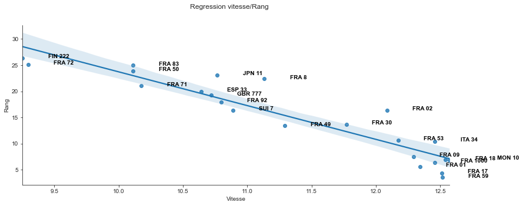

```python
plot_reg_and_annote(tmp_df,x='Vitesse',y='Rang')
```

```python
#Paramètres de la regression
from scipy import stats
slope, intercept, r_value, pv, se = stats.linregress(tmp_df['Vitesse'], tmp_df['Rang'])
(slope, intercept, r_value, pv, se)
```

```
(-6.450894347750231,
 88.22429813790833,
 -0.9307632930014001,
 1.2235996550878722e-10,
 0.5529727791374847)
```

**Notes importantes:**

- Nous notons une forte correlation de 0.93 entre le Rang moyen et la vitesse utile moyenne

**--> Cas de la vitesse utile dépuis le dernier classement**

```python
#Cas de la vitesse dépuis le dernier classement

#Construnction du dataframe qui donne le rang moyen et la vitesse moyenne par Voilier
tmp_df=df_final[['Depuis le dernier classement - VMG','Rang','Nat./Voile']].groupby(by='Nat./Voile' , dropna=True).agg({'Depuis le dernier classement - VMG':'mean','Rang':'mean','Nat./Voile':'count'})
tmp_df.columns= ["Vitesse","Rang",'Nombre de classement']

#Filtre sur les skippers qui ont abandonnés la compétition
tmp_df= tmp_df.loc[tmp_df['Nombre de classement']==tmp_df['Nombre de classement'].max()]

tmp_df.head()
```

| Nat./Voile | Vitesse | Rang | Nombre de classement |
| --- | --- | --- | --- |
| ESP 33 | 10.806432 | 19.993776 | 482 |
| FIN 222 | 9.378838 | 26.390041 | 482 |
| FRA 01 | 12.500207 | 5.599585 | 482 |
| FRA 02 | 12.247303 | 16.350622 | 482 |
| FRA 09 | 12.459959 | 7.545643 | 482 |

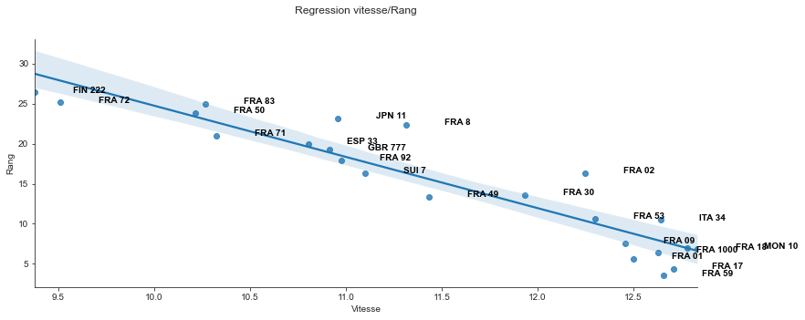

```python
plot_reg_and_annote(tmp_df,x='Vitesse',y='Rang')
```

```python
#Paramètres de la regression
from scipy import stats
slope, intercept, r_value, pv, se = stats.linregress(tmp_df['Vitesse'], tmp_df['Rang'])
(slope, intercept, r_value, pv, se)
```

```
(-6.388955541410501,
 88.6295512242186,
 -0.9302930663939226,
 1.3109684114301503e-10,
 0.5497307736337371)
```

**Notes importantes:**

- Nous notons une forte correlation de 0.93 entre le Rang moyen et la vitesse utile moyenne

**--> Cas de la vitesse utile dépuis 30 minutes**

```python
#Cas de la vitesse sur les 30 dernieres minutes

#Construnction du dataframe qui donne le rang moyen et la vitesse moyenne par Voilier
tmp_df=df_final[['Depuis 30 minutes - VMG','Rang','Nat./Voile']].groupby(by='Nat./Voile' , dropna=True).agg({'Depuis 30 minutes - VMG':'mean','Rang':'mean','Nat./Voile':'count'})
tmp_df.columns= ["Vitesse","Rang",'Nombre de classement']

#Filtre sur les skippers qui ont abandonnés la compétition
tmp_df= tmp_df.loc[tmp_df['Nombre de classement']==tmp_df['Nombre de classement'].max()]


tmp_df.head()
```

| Nat./Voile | Vitesse | Rang | Nombre de classement |
| --- | --- | --- | --- |
| ESP 33 | 10.813693 | 19.993776 | 482 |
| FIN 222 | 9.400415 | 26.390041 | 482 |
| FRA 01 | 12.415768 | 5.599585 | 482 |
| FRA 02 | 12.235685 | 16.350622 | 482 |
| FRA 09 | 12.365560 | 7.545643 | 482 |

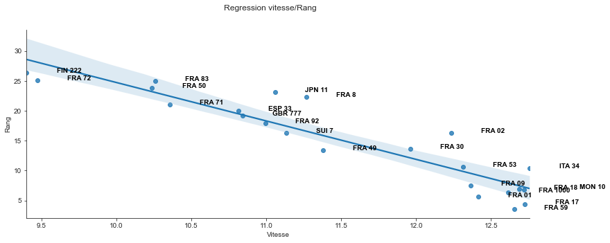

```python
#affichage de la regression
plot_reg_and_annote(tmp_df,x='Vitesse',y='Rang');
```

```python
#Paramètres de la regression
from scipy import stats
slope, intercept, r_value, pv, se = stats.linregress(tmp_df['Vitesse'], tmp_df['Rang'])
(slope, intercept, r_value, pv, se)
```

```
(-6.422139165720714,
 88.946110210971,
 -0.9242081773563052,
 3.0718654019042617e-10,
 0.5790785279141492)
```

**Notes importantes:**

- Nous notons une forte correlation de 0.92 entre le Rang moyen et la vitesse utile moyenne

**--> Regression avec la totalité des données**

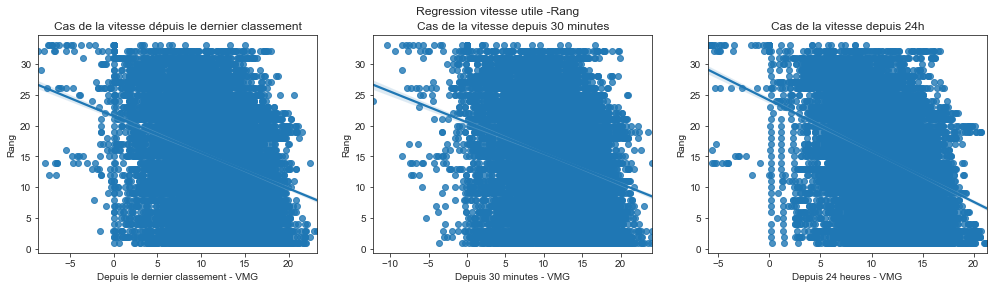

```python
fig, axes = plt.subplots(1, 3, figsize=(17,4))
fig.suptitle('Regression vitesse utile -Rang')
axes[0].set_title('Cas de la vitesse dépuis le dernier classement')
axes[1].set_title('Cas de la vitesse depuis 30 minutes')
axes[2].set_title('Cas de la vitesse depuis 24h')
fig.subplots_adjust(hspace=0.5)  # séparation verticale

sns.regplot(ax=axes[0],x=df_final['Depuis le dernier classement - VMG'], y=df_final['Rang']);
sns.regplot(ax=axes[1],x=df_final['Depuis 30 minutes - VMG'], y=df_final['Rang']);
sns.regplot(ax=axes[2],x=df_final['Depuis 24 heures - VMG'], y=df_final['Rang']);
```

```python
#Paramètres de la regression
from scipy import stats
slope, intercept, r_value, pv, se = stats.linregress(df_final['Depuis le dernier classement - VMG'], df_final['Rang'])
(slope, intercept, r_value, pv, se)
```

```
(-0.5852892770370852,
 21.523687049372988,
 -0.30282891893526526,
 1.5290603554137595e-288,
 0.015736584036429663)
```

**Notes importantes:**

- l'Utilisation de toutes les données pour la regression nous donne une faible correlation de 0.3 entre le rang et la vitesse

**--> Regression entre la vitesse et la vitesse utile**

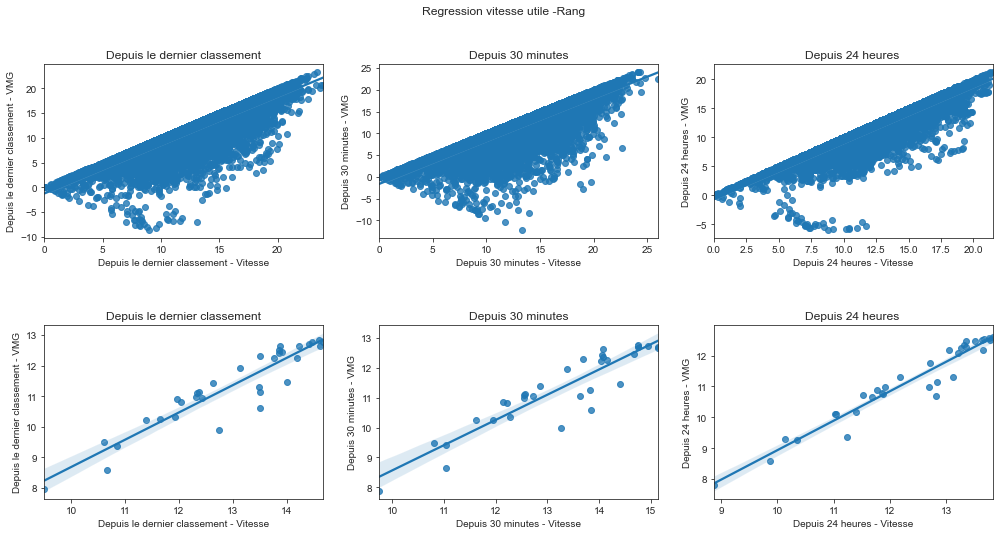

```python
fig, axes = plt.subplots(2, 3, figsize=(17,8))
fig.suptitle('Regression vitesse utile -Rang')
axes[0][0].set_title('Depuis le dernier classement')
axes[0][1].set_title('Depuis 30 minutes')
axes[0][2].set_title('Depuis 24 heures ')
fig.subplots_adjust(hspace=0.5)  # séparation verticale

sns.regplot(ax=axes[0][0],x=df_final['Depuis le dernier classement - Vitesse'], y=df_final['Depuis le dernier classement - VMG']);
sns.regplot(ax=axes[0][1],x=df_final['Depuis 30 minutes - Vitesse'], y=df_final['Depuis 30 minutes - VMG']);
sns.regplot(ax=axes[0][2],x=df_final['Depuis 24 heures - Vitesse'], y=df_final['Depuis 24 heures - VMG']);

#Cas de la moyenne
tmp_df= df_final[['Depuis le dernier classement - Vitesse','Depuis le dernier classement - VMG','Depuis 30 minutes - VMG','Rang','Depuis 30 minutes - Vitesse','Depuis 24 heures - Vitesse','Depuis 24 heures - VMG','Nat./Voile']].groupby(by='Nat./Voile' , dropna=True).mean()
tmp_df.head()
axes[1][0].set_title('Depuis le dernier classement')
axes[1][1].set_title('Depuis 30 minutes')
axes[1][2].set_title('Depuis 24 heures ')
sns.regplot(ax=axes[1][0],x=tmp_df['Depuis le dernier classement - Vitesse'], y=tmp_df['Depuis le dernier classement - VMG']);
sns.regplot(ax=axes[1][1],x=tmp_df['Depuis 30 minutes - Vitesse'], y=tmp_df['Depuis 30 minutes - VMG']);
sns.regplot(ax=axes[1][2],x=tmp_df['Depuis 24 heures - Vitesse'], y=tmp_df['Depuis 24 heures - VMG']);
```

```python
#Paramètres de la regression: Cas de la vitesse sur les derniers 24h
from scipy import stats
slope, intercept, r_value, pv, se = stats.linregress(df_final['Depuis 24 heures - Vitesse'], df_final['Depuis 24 heures - VMG'])
(slope, intercept, r_value, pv, se)
```

```
(0.9671478480775829,
 -0.6823636671410895,
 0.9201603430027419,
 0.0,
 0.003515857817747168)
```

```python
#Paramètres de la regression: Cas de la vitesse moyenne sur les derniers 24h
from scipy import stats
slope, intercept, r_value, pv, se = stats.linregress(tmp_df['Depuis 24 heures - Vitesse'], tmp_df['Depuis 24 heures - VMG'])
(slope, intercept, r_value, pv, se)
```

```
(0.9555320870745486,
 -0.6210188570226212,
 0.9670258509624842,
 5.651422520101879e-20,
 0.04519789162906644)
```

**Notes importantes:**

- La correlation entre la vitesse utile et la vitesse est très forte au vu du coefficient de correlation

**--> Regression entre la vitesse utile et la distance**

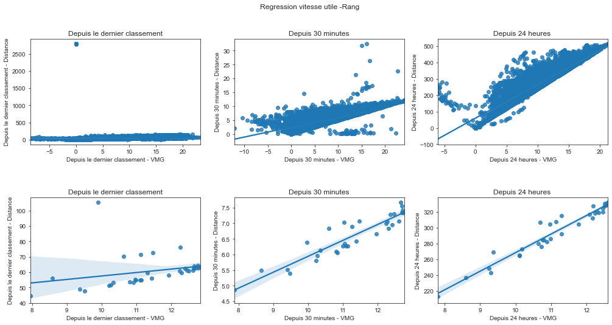

```python
fig, axes = plt.subplots(2, 3, figsize=(17,8))
fig.suptitle('Regression vitesse utile -Rang')
axes[0][0].set_title('Depuis le dernier classement')
axes[0][1].set_title('Depuis 30 minutes')
axes[0][2].set_title('Depuis 24 heures ')
fig.subplots_adjust(hspace=0.5)  # séparation verticale

sns.regplot(ax=axes[0][0],x=df_final['Depuis le dernier classement - VMG'],y=df_final['Depuis le dernier classement - Distance']);
sns.regplot(ax=axes[0][1],x=df_final['Depuis 30 minutes - VMG'],y=df_final['Depuis 30 minutes - Distance']);
sns.regplot(ax=axes[0][2],x=df_final['Depuis 24 heures - VMG'],y=df_final['Depuis 24 heures - Distance']);

#Cas de la moyenne
tmp_df= df_final[['Depuis le dernier classement - Distance','Depuis le dernier classement - VMG','Depuis 30 minutes - VMG','Depuis 30 minutes - Distance','Depuis 24 heures - Distance','Depuis 24 heures - VMG','Nat./Voile']].groupby(by='Nat./Voile' , dropna=True).mean()
tmp_df.head()
axes[1][0].set_title('Depuis le dernier classement')
axes[1][1].set_title('Depuis 30 minutes')
axes[1][2].set_title('Depuis 24 heures ')
sns.regplot(ax=axes[1][0],x=tmp_df['Depuis le dernier classement - VMG'],y=tmp_df['Depuis le dernier classement - Distance']);
sns.regplot(ax=axes[1][1],x=tmp_df['Depuis 30 minutes - VMG'],y=tmp_df['Depuis 30 minutes - Distance']);
sns.regplot(ax=axes[1][2],x=tmp_df['Depuis 24 heures - VMG'],y=tmp_df['Depuis 24 heures - Distance']);
```

**Notes importantes:**

- On observe naturellement une forte correlation entre la distance et la vitesse
- On observe egalement la présence des points abérrants: En effet la vitesse dépuis le dernier classement est à environt 2788.0 nm au premier classement du voilier . A quoi correspond cette valeur ? *TODO:* à determiner

**b) Visualisation du Rang et de la vitesse utile par voilier**

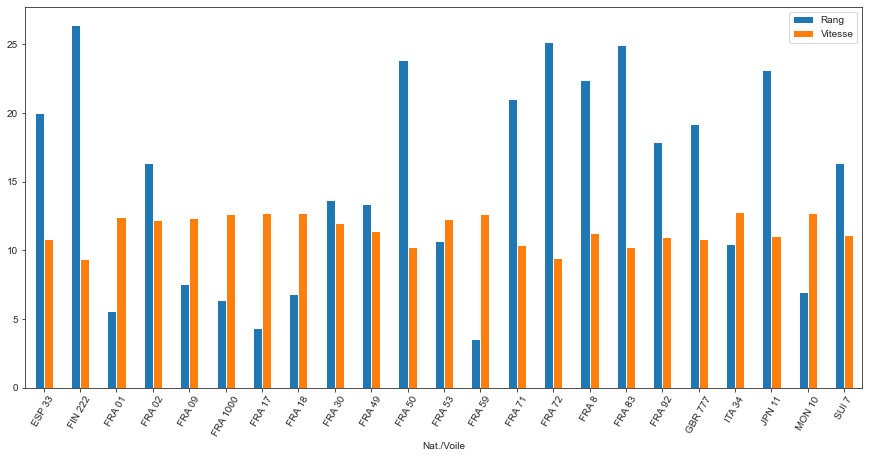

```python
#Visualisation du rang moyen par voilier

tmp_df[['Rang','Vitesse']].plot(kind='bar', rot=60,figsize=(15, 7));
```

**c) Impact de la présence d'un foil sur le classement et la vitesse des voiliers.**

**--> Visualisation de la moyenne avec barplot**

| Nombre de dérives voile | Depuis le dernier classement - VMG | Rang | Nombre de dérives voile |
| --- | --- | --- | --- |
| 2 | 10.977294 | 17.171101 | 2 |
| 2 asymétriques | 10.325519 | 21.029046 | 2 asymétriques |
| foiler | 11.474684 | 10.398734 | foiler |
| foils | 11.870329 | 12.415185 | foils |

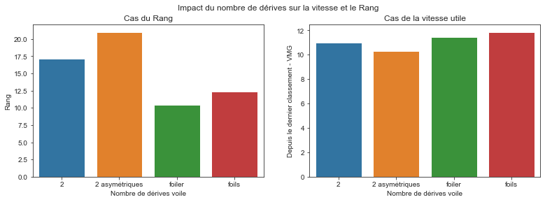

```python
tmp_df=df_final[['Depuis le dernier classement - VMG','Rang','Nombre de dérives voile']].groupby(by='Nombre de dérives voile' , dropna=True).agg({'Depuis le dernier classement - VMG':'mean','Rang':'mean','Nombre de dérives voile':'max'})

fig, axes = plt.subplots(1, 2, figsize=(13,4))
fig.suptitle('Impact du nombre de dérives sur la vitesse et le Rang')
axes[0].set_title('Cas du Rang')
axes[1].set_title('Cas de la vitesse utile')

# tableau lignes x colonnes
sns.barplot(ax=axes[0],data=tmp_df, x='Nombre de dérives voile', y='Rang', ci=None);
sns.barplot(ax=axes[1],data=tmp_df, x='Nombre de dérives voile', y='Depuis le dernier classement - VMG', ci=None);

tmp_df.head()
```

### Remarques sur l'analyse de l'mpact de la présence d'un foil sur le classement et la vitesse des voiliers.

- Les voliers avec le foils ont la vitesse utile moyenne la plus elévée
- Les voliers avec le foils sont les plus mieux classés après ceux avec le foilier

**--> Visualisation avec scatterplot**

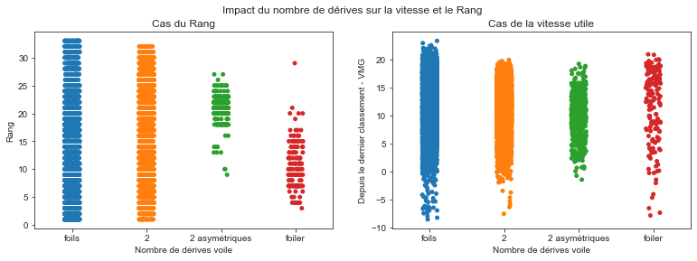

```python
tmp_df=df_final[['Depuis le dernier classement - VMG','Rang','Nombre de dérives voile']]

fig, axes = plt.subplots(1, 2, figsize=(13,4))
fig.suptitle('Impact du nombre de dérives sur la vitesse et le Rang')
axes[0].set_title('Cas du Rang')
axes[1].set_title('Cas de la vitesse utile')

sns.stripplot(ax=axes[0],data=tmp_df, x='Nombre de dérives voile', y='Rang');
sns.stripplot(ax=axes[1],data=tmp_df, x='Nombre de dérives voile', y='Depuis le dernier classement - VMG');
```

**--> Visualisation avec heatmap**

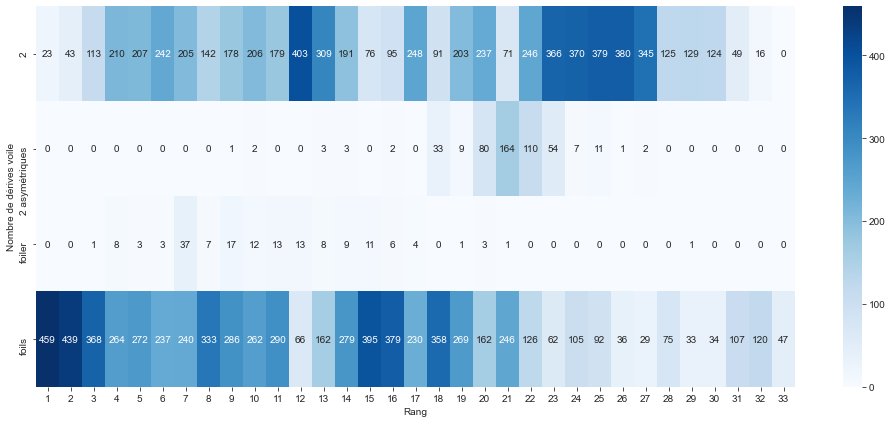

```python
tmp_df=df_final[['Depuis le dernier classement - VMG','Rang','Nombre de dérives voile']]

fig, axes = plt.subplots(1, 1, figsize=(17,7))

tab = pd.crosstab(tmp_df['Nombre de dérives voile'], tmp_df['Rang'])
sns.heatmap(tab, cmap='Blues', annot=True, fmt='d');
```

### Remarques sur l'analyse de l'mpact de la présence d'un foil sur le classement et la vitesse des voiliers.

- Les voliers avec le foils ont la plus grande cardinalité pour le rang 1

**d) Visualisation de la distance parcourue par voilier/Skipper.**

|  | Skipper | Nat./Voile | Depuis le dernier classement - Distance |
| --- | --- | --- | --- |
| 0 | Alan Roura | SUI 7 | 26391.2 |
| 1 | Alex Thomson | GBR 99 | 11119.0 |
| 2 | Alexia Barrier | FRA 72 | 23010.6 |
| 3 | Ari Huusela | FIN 222 | 23598.9 |
| 4 | Armel Tripon | FRA 02 | 29289.7 |

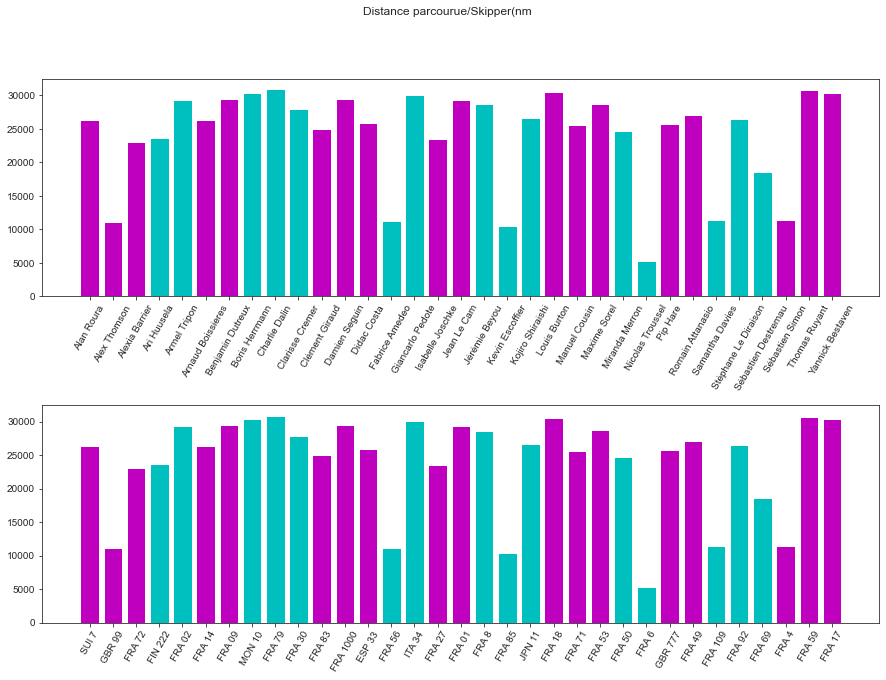

```python
tmp_df=df_final[['Depuis le dernier classement - Distance','Skipper','Nat./Voile']].groupby(by=['Skipper','Nat./Voile'] , dropna=True).agg({'Depuis le dernier classement - Distance':'sum'})
tmp_df=tmp_df.reset_index()
fig = plt.figure(figsize=(15, 10))
fig.suptitle('Distance parcourue/Skipper(nm')

# tableau lignes x colonnes
[ax1, ax2] = fig.subplots(2, 1, sharey=True)
fig.subplots_adjust(hspace=0.5)  # séparation verticale
ax1.bar(x=tmp_df['Skipper'], height=tmp_df['Depuis le dernier classement - Distance'], color=list('mmmccmmccc'));
ax2.bar(x=tmp_df['Nat./Voile'], height=tmp_df['Depuis le dernier classement - Distance'], color=list('mmmccmmccc'));
plt.setp(ax1.xaxis.get_majorticklabels(), rotation=60)
plt.setp(ax2.xaxis.get_majorticklabels(), rotation=60)

tmp_df.head()
```

### Note importante sur la visualisation de la distance parcourue par skipper/voilier

```
-- Ces graphiques nous permettent déjà de remarquer assez rapidement les skippers qui ont abandonné la course
```

**e) Visualisation du rang par voilier sur le temps**

| Skipper Date classement | Alex Thomson | Alexia Barrier | Ari Huusela | Armel Tripon | Arnaud Boissieres | Benjamin Dutreux | Boris Herrmann | Charlie Dalin | Clarisse Cremer |
| --- | --- | --- | --- | --- | --- | --- | --- | --- | --- |
| 2020-11-08 14:00:00 | 8.0 | 27.0 | 31.0 | 26.0 | NaN | 25.0 | 2.0 | NaN | 22.0 |
| 2020-11-08 15:00:00 | 3.0 | 28.0 | 32.0 | 10.0 | NaN | 24.0 | 5.0 | 2.0 | 22.0 |
| 2020-11-08 17:00:00 | 4.0 | 31.0 | 32.0 | 7.0 | NaN | 23.0 | 5.0 | 2.0 | 20.0 |
| 2020-11-08 21:00:00 | 6.0 | 32.0 | 30.0 | 3.0 | 28.0 | 21.0 | 7.0 | 5.0 | 20.0 |
| 2020-11-09 04:00:00 | 19.0 | 29.0 | 30.0 | 6.0 | 26.0 | 12.0 | 22.0 | 17.0 | 13.0 |

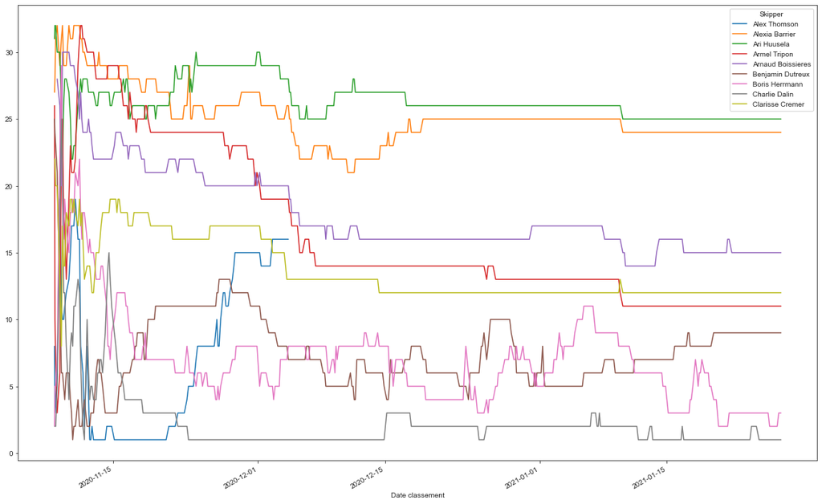

```python
tmp_df= df_final[['Rang','Skipper']]

tmp_df=pd.pivot_table(tmp_df,values='Rang',columns=['Skipper'],index=['Date classement'])
tmp_df.iloc[:,1:10].plot(figsize=(20, 13));

tmp_df.iloc[:,1:10].head()
```

**f) Visualisation de la vitesse par voilier sur le temps**

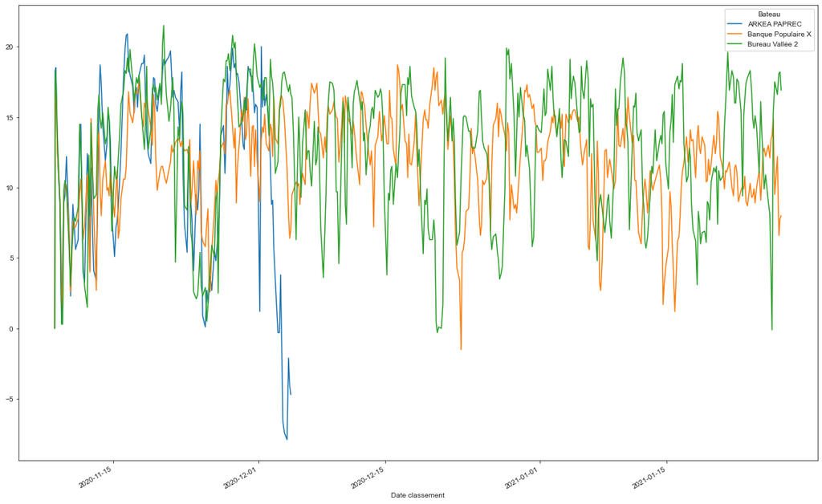

```python
tmp_df= df_final[['Depuis le dernier classement - VMG','Bateau']]

tmp_df=pd.pivot_table(tmp_df,values='Depuis le dernier classement - VMG',columns=['Bateau'],index=['Date classement'])
tmp_df.iloc[:,1:4].plot(figsize=(20, 13));
```

### 8) Visualisation du parcours des voiliers sur la carte

**a) Utilisation de ipyleaflet**

**-- Cas de deux skippers**

```python
from ipyleaflet import Map,Icon, Polyline
from ipyleaflet import AwesomeIcon

tmp_df = df_final.loc[df_final['Nat./Voile'] =='FRA 79',['Latitude','Longitude']]
tmp_df2 = df_final.loc[df_final['Nat./Voile'] =='FRA 6',['Latitude','Longitude']]


line1 = Polyline(
    locations=tmp_df.values.tolist(),
    color="red" ,
    fill=False,
    weight=1,
    opacity=0.5,
    dash_array='2, 2'
)

line2 = Polyline(
    locations=tmp_df2.values.tolist(),
    color="blue" ,
    fill=False,
    weight=1,
    dashAjrray='3, 3',
    dashOffset='1'
)

depart =tuple(tmp_df.iloc[0])


depart_marker = Marker(location=depart, draggable=True,title='Depart')

center = tmp_df[['Latitude','Longitude']].mean()-[-20,1]
m = Map( center=tuple(center), zoom=2)
m.add_layer(line1)
m.add_layer(line2)

m.add_layer(depart_marker)



m
```

### Une capture de la carte

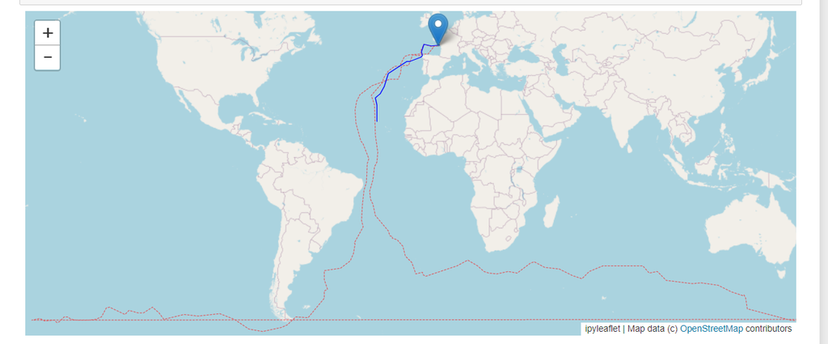

**-- Cas de tous les skippers: la carte est disponible dans le fichier cartographie.html**

```python
from ipyleaflet import Map,Icon, Polyline,Popup,Marker
from ipyleaflet import AwesomeIcon
from ipywidgets import HTML,Layout


voiliers= df_final['Nat./Voile'].unique()

#Les coordonnées geographiques par voilier
coords= {}
for voilier in voiliers:
    coords[voilier]=df_final.loc[df_final['Nat./Voile'] ==voilier,['Latitude','Longitude']].values.tolist()


#Tableau des couleurs
choices=[ "red", "blue", "green", "yellow", "purple", "orange", "white", "black" ]
colors=[]
for i in range(0,len(coords)):
    colors.append(choices[i%(len(choices))])

#Tableau des chemins
chemins=[]
idx=0
for voilier in coords:
    chemin = Polyline(
        locations=coords[voilier],
        color=colors[idx],
        fill=False,
        weight=1,
        opacity=0.5,
        dash_array='2, 2'
    )

    chemins.append(chemin)
    idx+=1


#creation de la carte de la carte
center = tuple(tmp_df[['Latitude','Longitude']].mean()-[-20,1])
m = Map( center=center, zoom=2)

#Ajout des chemins dans la carte
for chemin in chemins:
    m.add_layer(chemin)

#Ajout du point de départ
depart =tuple(df_final[['Latitude','Longitude']].iloc[0])
depart_marker = Marker(location=depart, draggable=True,title='Depart')
m.add_layer(depart_marker)
#Affichage de la carte

#Ajout du parcourt du premier avec le bateau
df_premier= df_final.loc[df_final['Nat./Voile']=='FRA 17',['Latitude','Longitude','Lien image voile']]
df_premier= df_premier.resample('W').last()
idx=0
for point in df_premier.values.tolist():
    icon = Icon(icon_url='https://www.vendeeglobe.org'+point[-1], icon_size=[30, 40], icon_anchor=[22,30])
    title=df_premier.index[idx].strftime("%m/%d/%Y %H:%M:%S")
    weekly_marker=Marker(location=point[0:2], draggable=True,alt=title,title=title,icon=icon)

    m.add_layer(weekly_marker)
    idx+=1


m.save('cartographie.html', title='Cartographie Vendée globe')

m
```

## Une capture de la carte

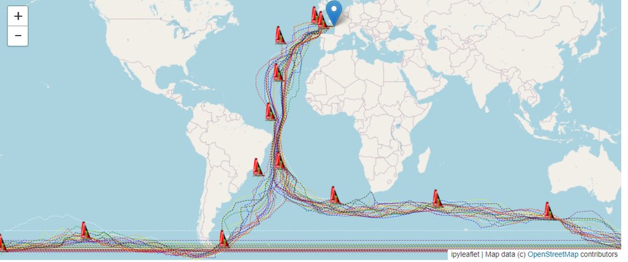

**b) Utilisation de plotly**

```python
import plotly
from plotly.offline import iplot, init_notebook_mode

import chart_studio.plotly as py
import plotly.graph_objs as go
init_notebook_mode(connected=True)

voiliers= []
voiliers.append(df_final.loc[df_final['Nat./Voile'] =='FRA 18',['Latitude','Longitude','Rang']])
voiliers.append(df_final.loc[df_final['Nat./Voile'] =='FRA 79',['Latitude','Longitude','Rang']])

voiliers[0] = voiliers[0].sample(frac=0.1, replace=True)
voiliers[1] = voiliers[1].sample(frac=0.1, replace=True)

data = []
colors = ['red','blue']

for i in (0,1):
    data.append(go.Scattergeo(
        lon = voiliers[i]['Longitude'],
        lat = voiliers[i]['Latitude'],
        marker = dict(
            size = voiliers[i]['Rang']/2,
            color = colors[i],
            opacity = .4,
            line = dict(width = 0)
        ),
    ) )


data[0]['mode'] = 'markers'


layout = {
    'title': 'Parcours des des Voiliers',
    'geo': {
        'showcountries': True,
        'showframe': False,
        'showcoastlines': False,
        'projection': {
            'type': 'mercator'  # 'mercator'
        }
    }
}

fig = {'data': data, 'layout': layout}
iplot(fig, validate=False, filename='d3-world-map')
```

[interactive chart not shown]